# DDS_LiveSessionAssignment_U5 - Functions in R

Najeeb Zaidi

July 30, 2016

# Introduction

The functions created in this exercise allow conversion from one base to another. For record, R Studio (v3.3.0) sessionInfo is listed in the notes section.

```r
P7 <- function(n, base = 7)
{
  if (n == 0)
    return(c())
  if (n < 0)
    stop(simpleError("A Negative number cannot be used with this function"))
  nDigits <- ceiling(log(n + 1, 7))
  powers <- 7 ^ (0:nDigits)
  out <- diff(n %% powers)/powers[-length(powers)]
  out1 <- rev(out)
  out2 <- paste(out1, collapse = '')
  out2 = as.numeric(out2)
  out3 <- 1:out2
  return(out3)
}
# To use the function, enter the integer (n) and it will
# return the series of the first (n) integer up to the (n) correspondent
# number in base 7. The functions also checks for null and negative values.

P7(55)
```

```
##   [1]   1   2   3   4   5   6   7   8   9  10  11  12  13  14  15  16  17
##  [18]  18  19  20  21  22  23  24  25  26  27  28  29  30  31  32  33  34
##  [35]  35  36  37  38  39  40  41  42  43  44  45  46  47  48  49  50  51
##  [52]  52  53  54  55  56  57  58  59  60  61  62  63  64  65  66  67  68
##  [69]  69  70  71  72  73  74  75  76  77  78  79  80  81  82  83  84  85
##  [86]  86  87  88  89  90  91  92  93  94  95  96  97  98  99 100 101 102
## [103] 103 104 105 106
```

### Item 2: A function called “Base10to7” which takes one argument x, and will convert a given decimal number to base 7.

```r
Base10to7 <- function(n, base = 7)
{
  if (n == 0)
    return(c())
  if (n < 0)
    stop(simpleError("A Negative number cannot be used with this function"))

  nDigits <- ceiling(log(n + 1, 7))
  powers <- 7 ^ (0:nDigits)
  out <- diff(n %% powers)/powers[-length(powers)]
  return(rev(out))
}
# For example :

Base10to7(25)
```

```
## [1] 3 4
```

### Item 3: Write a function called “Base7to10” which takes an argument y, and converts a base number 7 to decimal.

```r
Base7to10 = function(base_number, base = 7)
  {
  split_base = strsplit(as.character(base_number), split = "")
  return(sapply(split_base, function(x) sum(as.numeric(x) * base ^ (rev(seq_along(x) - 1)))))
  }

# To use the function, just simple enter the desired integer (to be considered in base 7) and it will return the correspondent number in base 10. For example:
Base7to10(5)
```

```
## [1] 5
```

### Item 4: A Generalized function to take any form & especially steps 1, 2 and 3 above:

```r
numberInBase <- function(number,base)
  {
  numberInBaseRecur <- function(number,base)
    {
    lastDigit <- function(number,base) number %% base
    if (number == 0) result <- c(0)
    else result <- c(numberInBaseRecur(number %/% base,base),
                     lastDigit(number,base))
    result
    }
  result <- numberInBaseRecur(number,base)
  while (result[1] == 0 && length(result) > 1) result <- result[-1]
  result
  }
use <- function(digiseq)
  {
  digits <- c(as.character(0:9),LETTERS)
  paste(sapply(digiseq,function(x)digits[x + 1]),collapse = "")
  }
use(numberInBase(21,2))
```

```
## [1] "10101"
```

```r
# To use the function use(numberInBase(m,n), just simple enter a desired integer as first parameter and the desired base value as second parameter and the function will return the input m number in the selected base n. For example:

use(numberInBase(21,2))
```

```
## [1] "10101"
```

```r
use(numberInBase(30,8))
```

```
## [1] "36"
```

```r
use(numberInBase(556,10))
```

```
## [1] "556"
```

```r
use(numberInBase(556,16))
```

```
## [1] "22C"
```

### Item 5A: Plot a histogram chart for item 4:

If we apply the general conversion function (in Item 4: use(numberInBase(m,n)) to plot a chart with 2 numbers, the first one being the input number m (assumed in base 10) and the second one its equivalent in base n, the graph would look like:

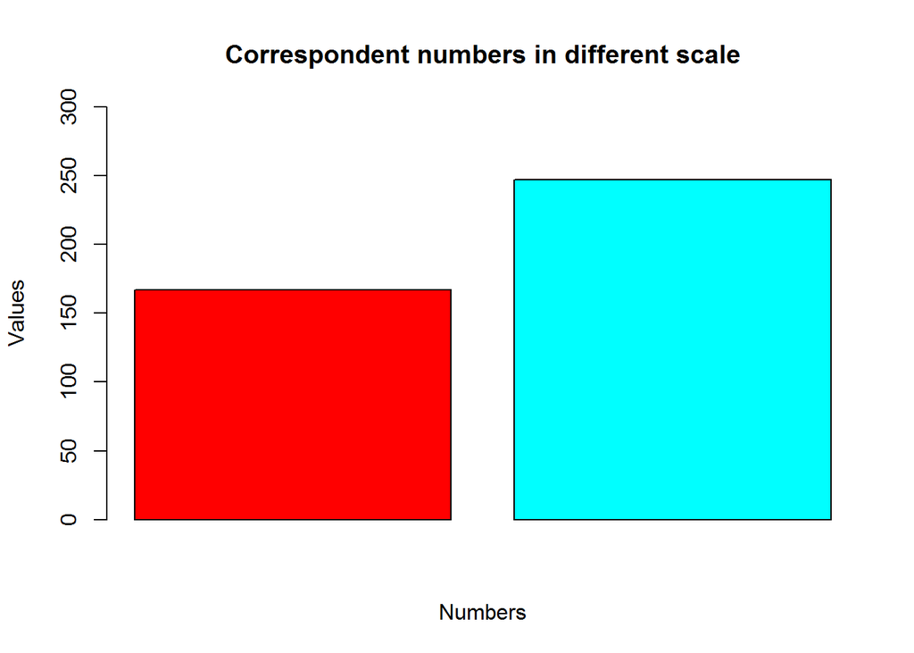

```r
m <- 167
n <- 8
c <- use(numberInBase(m , n)) # This returns 247 as the equivalent of 167 (b10) in base 8
v <- c(m , c)
v1 <- as.numeric(v)

# using additional arguments to customize our graph
v1LabelMain <- "Correspondent numbers in different scale"
v1LabelX <- "Numbers"
v1LabelY <- "Values"
v1RainbowColors <- rainbow(length(v1))

# Y axis range could be adjusted using: ylim<-max(v1) + v1LimY <- c(0, ylim) as well as other customizations are possible ie showing legend, values, adding text, dividing the chart in panels, etc.
barplot(height = v1, main = v1LabelMain, xlab = v1LabelX, ylab = v1LabelY, ylim = c(0,300), col = v1RainbowColors)
```

Required features listed are: Line width = 3 Shaded Color = grey40 Text at (23, 0.025) cex = 1.2;

### Item 6: Generalized Plot

I have generalized this function plot to draw a sample of size 1000 from a normal distribution with mean 0 and standard deviation 30, as follows:

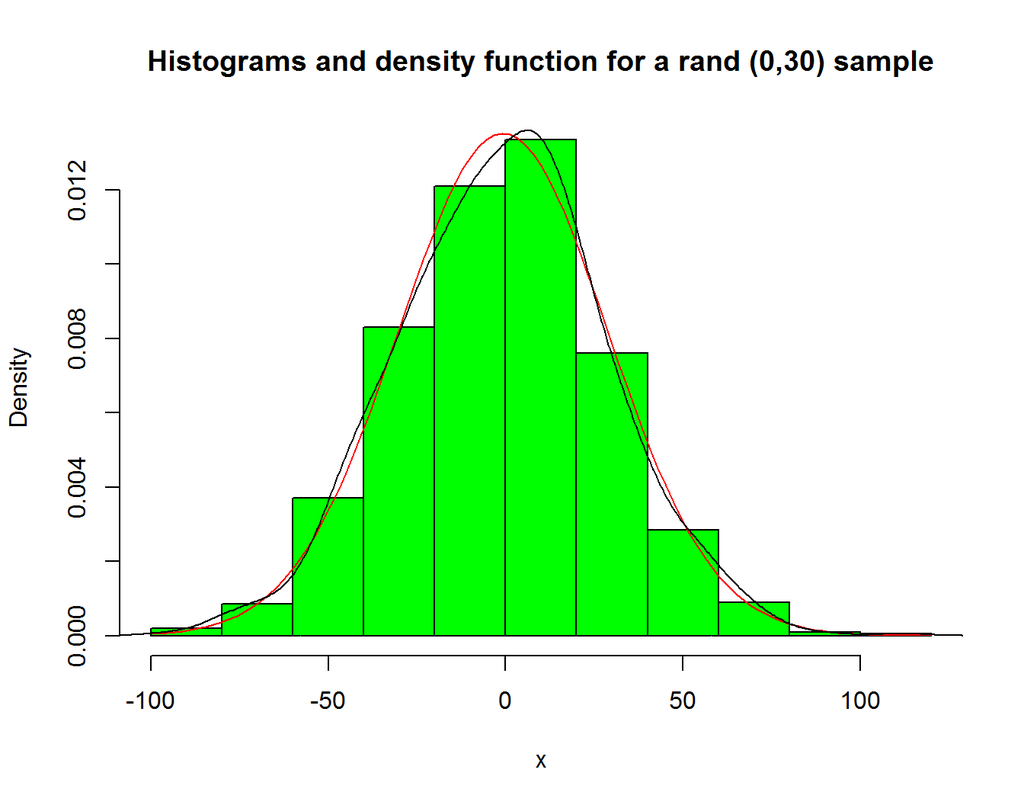

```r
x <- rnorm(1000, 0, 30)
m = mean(x)
s = sd(x)
hist(x, col = "green", probability = TRUE, main = "Histograms and density function for a rand (0,30) sample")

# Adding vertical lines to capture 95% of the sample
lines(c(-s*1.96,-s*1.96), c(0, dnorm(-s*1.96)), col = "green")
lines(c(s*1.96,s*1.96), c(0, dnorm(s*1.96)), col = "green")

# Adding the distribution curve with parameters m and s
curve(dnorm(x, mean = m, sd = s), col = "red", add = TRUE)
# Adding the probability density curve
lines(density(x), col = "black")
```

### References:

It would be possible to generalize the function plot. For further references:

```
 * https://cran.r-project.org/web/packages/ggfortify/vignettes/plot_dist.html
 * https://tomizonor.wordpress.com/2013/05/11/distribution-density-histogram/
 * http://nicercode.github.io/guides/plotting/
```

### Notes:

[session information not shown]